# **Exoplanets and Solar System Planets: Data Analysis & Visualization**

*Author: Anton Zaitsev*  
*Date: January 26, 2024*

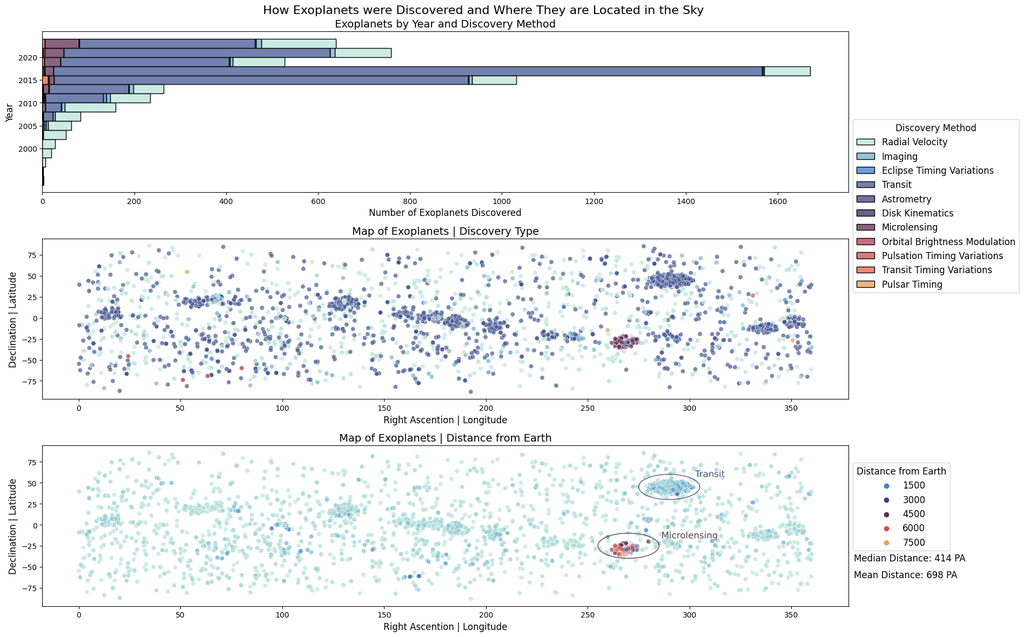

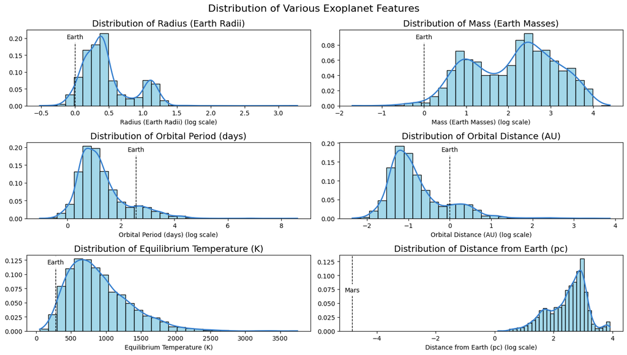

[figure not shown]

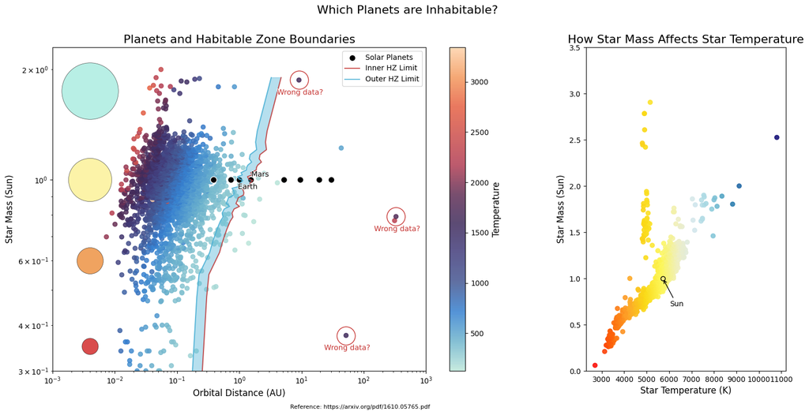

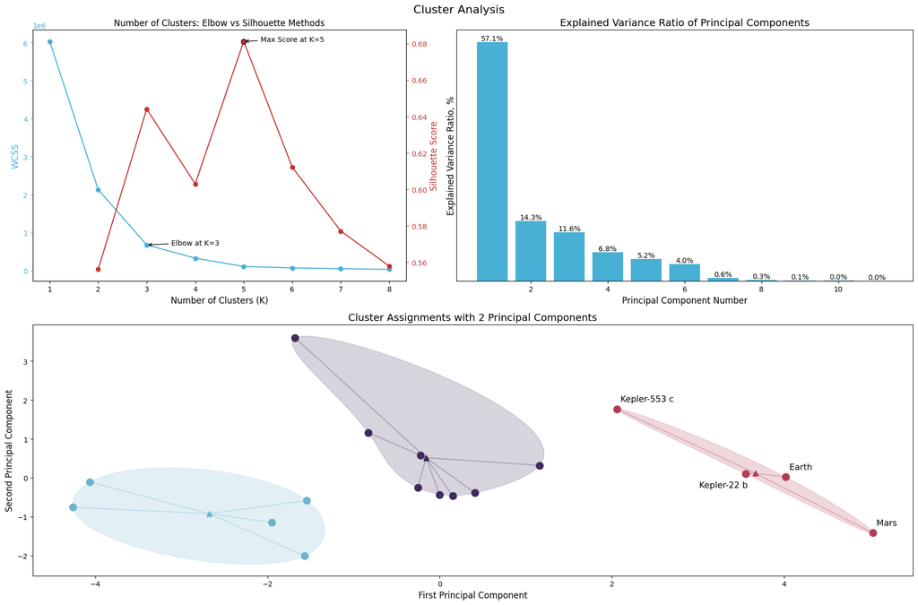

|  | Planet | Star | Distance (PC) | Temperature (K) | Time to Get (Years) | Type | Mass (Earth) | Radius (Earth) | Orbital Period (days) |
| --- | --- | --- | --- | --- | --- | --- | --- | --- | --- |
| 0 | Earth | Sun | 0.000000 | 279.0 | 0.0 | Earth | 1.0 | 1.0 | 365.3 |
| 1 | Mars | Sun | 0.000015 | 226.0 | 0.6 | Mars | 0.1 | 0.5 | 687.0 |
| 2 | Kepler-553 c | Kepler-553 | 728.500000 | 235.6 | 29629157.2 | Gas Giant | 317.5 | 11.4 | 328.2 |
| 3 | Kepler-22 b | Kepler-22 | 194.600000 | 264.1 | 7916102.3 | Super Earth, Super Ocean | 22.6 | 2.2 | 289.9 |

[figure not shown]

## References

### NASA Exoplanet Archive

https://exoplanetarchive.ipac.caltech.edu/cgi-bin/TblView/nph-tblView?app=ExoTbls&config=PS

NASA Exoplanet Archive dataset contains information on confirmed planets outside of the Solar System, e.g. planet mass, radius, planet discovery method, orbital period, etc.

### Solar System Major Bodies Data

https://www.kaggle.com/datasets/jaredsavage/solar-system-major-bodies-data

The Solar System Planets dataset contains information on major bodies inside the Solar System, including planets, such as Earth, Mars, Venus, etc. It includes information on body's attributes, such as mass, density, etc.

### Equilibrium Temperatures for Solar Planets

http://astro.vaporia.com/start/equilibriumtemperature.html

Data for equilibrium temperatures for planets inside the Solar System.

## References

### The Distances from the Solar Planets to the Earth

https://promenade.imcce.fr/en/pages5/573.html

Data for the distances for planets inside the Solar System to Earth.

### Habitable Zone Boudaries Calculation

https://www.planetarybiology.com/calculating_habitable_zone.html

Formula on how to calculate star inner and outer habitable zone boundaries.

### Solar System Habitable Zone Boundaries

https://www.britannica.com/science/habitable-zone

Information on the habitable zone of the Sun.

## References

### The Habitability of Planets Orbiting M-dwarf Stars

https://arxiv.org/pdf/1610.05765.pdf

In this paper, A. L. Shields, S. Ballard and J. A. Johnson provide a "comprehensive picture of the current knowledge of M-dwarf planet occurrence and habitability based on work done in this area over the past decade". This paper was only used as an inspiration for the 'Habitable Zone Boundaries' plot.

### Sun Fact Sheet

https://nssdc.gsfc.nasa.gov/planetary/factsheet/sunfact.html

Data on Sun.

## References

### Sun Age

https://ui.adsabs.harvard.edu/abs/1989ApJ...339.1156G/abstract#:~:text=The%20age%20of%20the%20sun,4.49%20%2B%20or%20%2D%200.04%20Gyr.

Approximate Sun age.

### Kepler-22 b and Kepler-553 c

Kepler-22 b: https://exoplanets.nasa.gov/exoplanet-catalog/1599/kepler-22b/

Kepler-553 c: https://exoplanets.nasa.gov/exoplanet-catalog/6009/kepler-553-c/

Information and animation for these 2 exoplanets.